# Homework 3: Some of My Best Friends are Zombies!

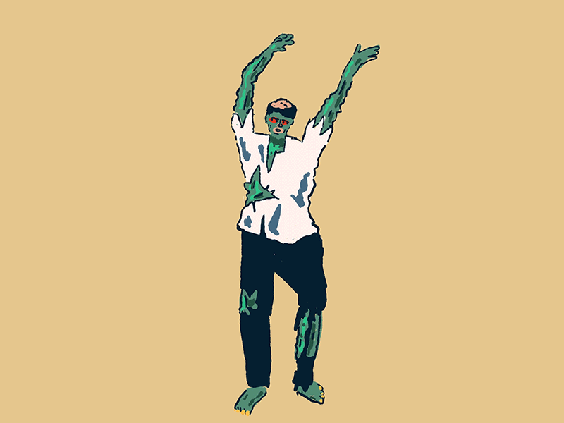

# Preliminaries:

1. Installing and getting needed packages into the environment
2. Importing the dataset into the environment.

```r
library(curl)
```

```r
library(ggplot2) #I would've just called library(tidyverse) but R is telling me to update and I really don't want to. R updates terrify me.
library(rmdformats)
#reesehs: R updates are scary but you will basically just redownload the software and it will be the exact same, so don't put off updating!
#vbhavya: Yes, I actually did end up having to update my R, but it's still giving an error with the 'tidyr' package. I have no idea why,

f <- curl("https://raw.githubusercontent.com/fuzzyatelin/fuzzyatelin.github.io/master/AN588_Fall23/zombies.csv") #importing the zombies data set from Chris' github
d <- read.csv(f, header = TRUE, sep = ",", stringsAsFactors = FALSE)
head(d)
```

```
##   id first_name last_name gender   height   weight zombies_killed
## 1  1      Sarah    Little Female 62.88951 132.0872              2
## 2  2       Mark    Duncan   Male 67.80277 146.3753              5
## 3  3    Brandon     Perez   Male 72.12908 152.9370              1
## 4  4      Roger   Coleman   Male 66.78484 129.7418              5
## 5  5      Tammy    Powell Female 64.71832 132.4265              4
## 6  6    Anthony     Green   Male 71.24326 152.5246              1
##   years_of_education                           major      age
## 1                  1                medicine/nursing 17.64275
## 2                  3 criminal justice administration 22.58951
## 3                  1                       education 21.91276
## 4                  6                  energy studies 18.19058
## 5                  3                       logistics 21.10399
## 6                  4                  energy studies 21.48355
```

# Assignment problems

## Question 1: Calculating the population means and standard deviations.

```r
#writing a function for population standard deviation of variable y
stdev <- function(y) {
  sqrt(sum((y - mean(y))^2)/length(y))}

#reesehs: so smart! I really liked how you created a function instead of typing it out for everyone. This for sure makes the code more efficient.

#height
mean(d$height)
```

```
## [1] 67.6301
```

```r
stdev(d$height)
```

```
## [1] 4.30797
```

```r
#weight
mean(d$weight)
```

```
## [1] 143.9075
```

```r
stdev(d$weight)
```

```
## [1] 18.39186
```

```r
#No. of zombies killed
mean(d$zombies_killed)
```

```
## [1] 2.992
```

```r
stdev(d$zombies_killed)
```

```
## [1] 1.747551
```

```r
#Years of education
mean(d$years_of_education)
```

```
## [1] 2.996
```

```r
stdev(d$years_of_education)
```

```
## [1] 1.675704
```

```r
#Age
mean(d$age)
```

```
## [1] 20.04696
```

```r
stdev(d$age)
```

```
## [1] 2.963583
```

## Question 2: Use {ggplot} to make boxplots of each of these variables by gender.

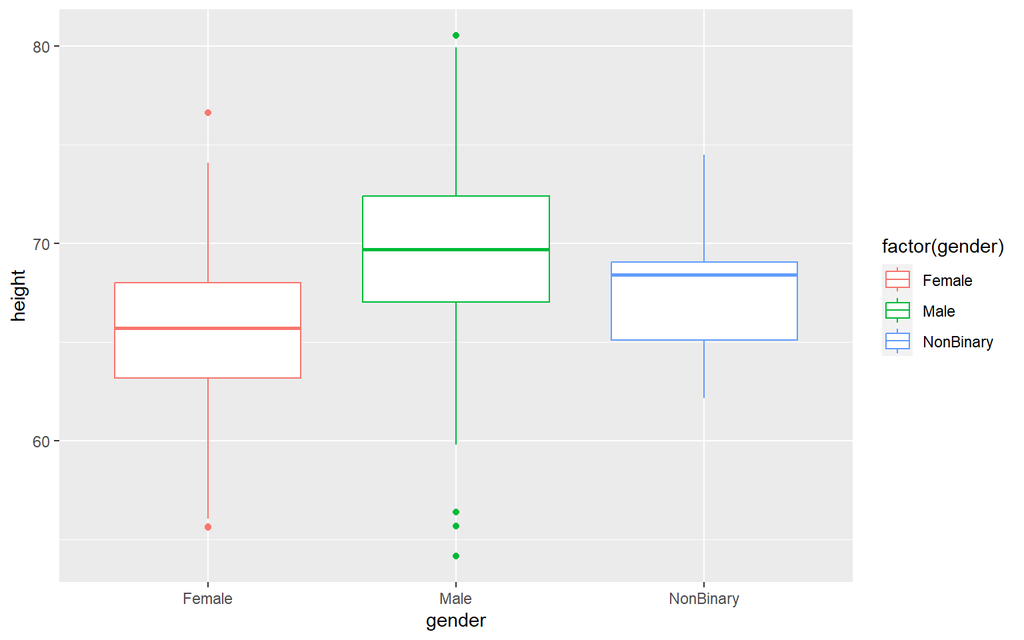

```r
# Variable = height
p <- ggplot(data = d, aes(x = gender, y = height,
    color = factor(gender))) + geom_boxplot()
p
```

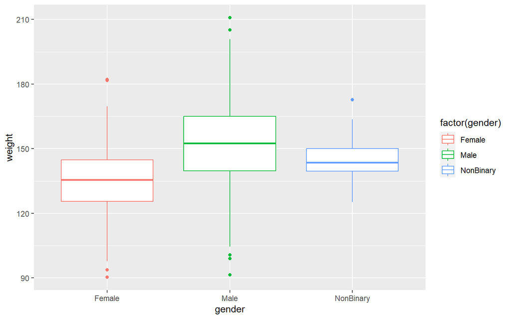

```r
# Variable = weight
p <- ggplot(data = d, aes(x = gender, y = weight,
    color = factor(gender))) + geom_boxplot()
p
```

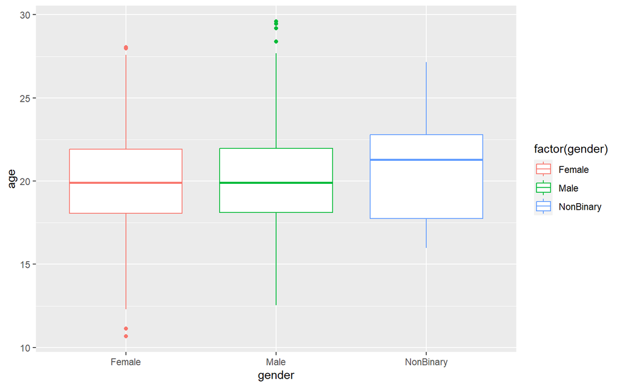

```r
# Variable = age
p <- ggplot(data = d, aes(x = gender, y = age,
    color = factor(gender))) + geom_boxplot()
p
```

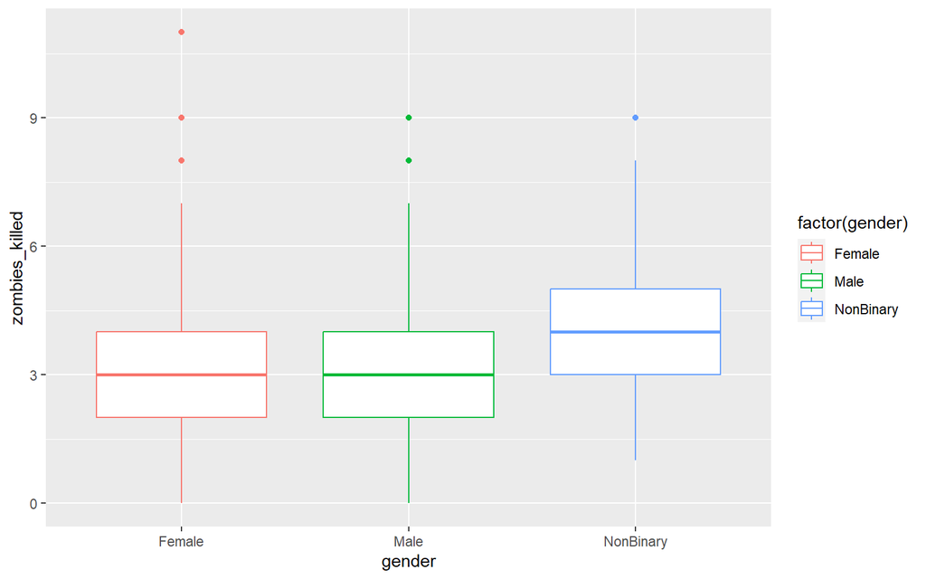

```r
# Variable = No of zombies killed
p <- ggplot(data = d, aes(x = gender, y = zombies_killed,
    color = factor(gender))) + geom_boxplot()
p
```

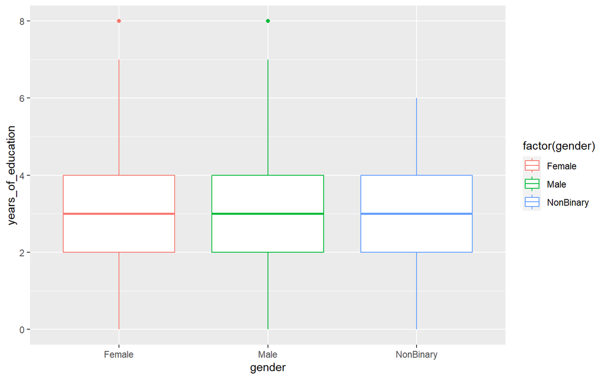

```r
# Variable = Years of education
p <- ggplot(data = d, aes(x = gender, y = years_of_education,
    color = factor(gender))) + geom_boxplot()
p
```

```r
#reesehs: this all looks like wonderful code. I especially like that you colored the boxes by gender.
```

## Question 3: Use {ggplot} to make scatterplots of height and weight in relation to age. Do these variables seem to be related? In what way?

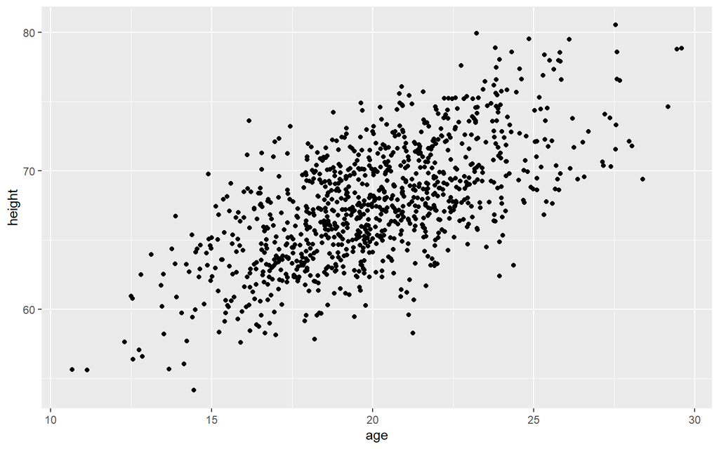

```r
#Age v/s height

p <- ggplot(data = d, aes(x = age, y = height)) + geom_point()
p
```

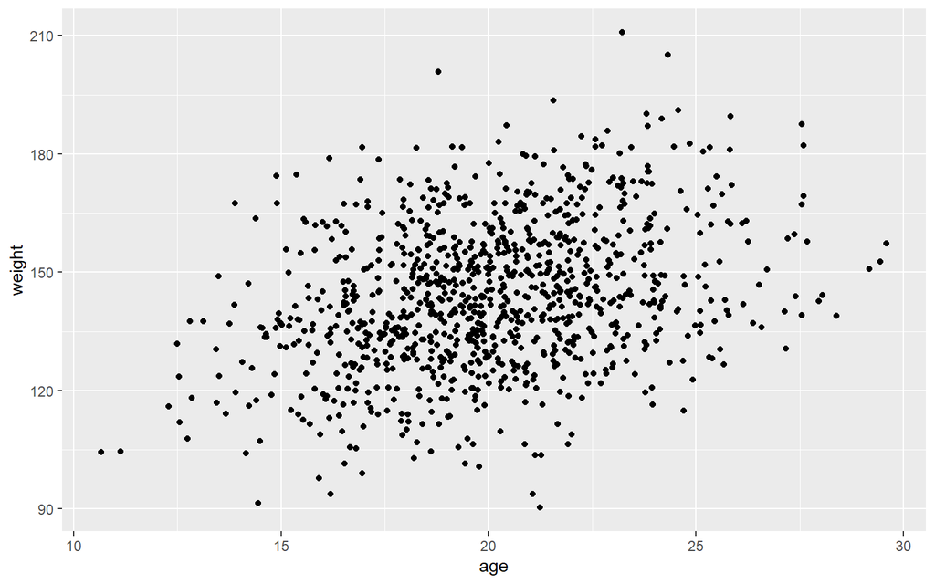

```r
#Age v/s weight

p <- ggplot(data = d, aes(x = age, y = weight)) + geom_point()
p
```

Yes, there seems to be a positive correlation between age and both height and weight. This means, as age increases, both height and weight are likely to increase as well.

However, the relationship between age and height seems to be more correlated upto 25 years of age, after which it flattens.

## Question 4: Using histograms and Q-Q plots, check whether the quantitative variables seem to be drawn from a normal distribution. Which seem to be and which do not (hint: not all are drawn from the normal distribution)? For those that are not normal, can you determine from which common distribution they are drawn?

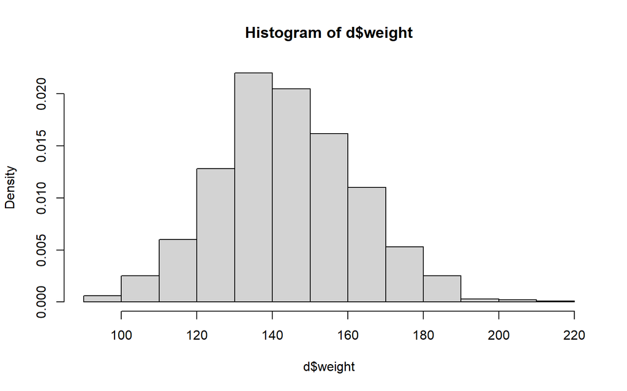

```r
#Variable = weight
hist(d$weight, probability = TRUE)
```

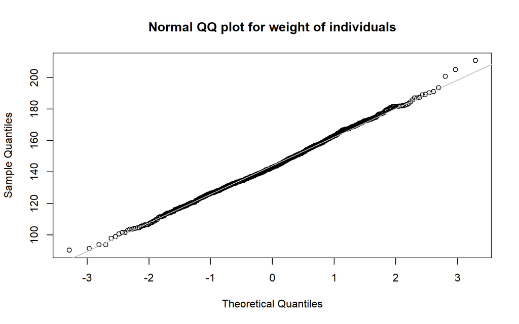

```r
qqnorm(d$weight, main = "Normal QQ plot for weight of individuals")
qqline(d$weight, col = "gray") # fits with the QQ-line quite well (except the tails), can be roughly estimated to a normal distribution
```

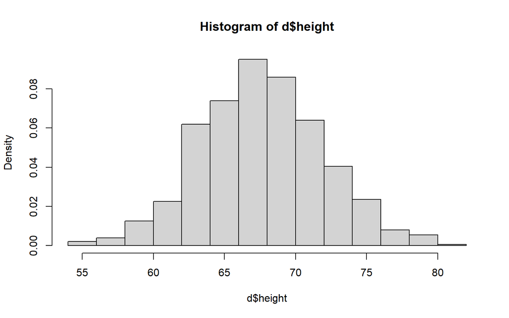

```r
#Variable = height
hist(d$height, probability = TRUE)
```

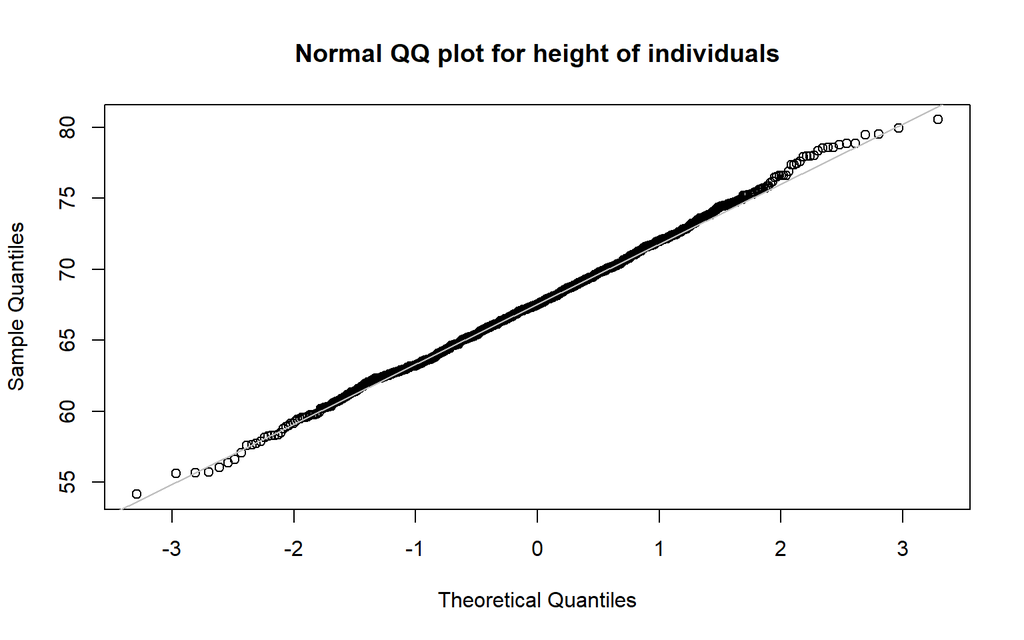

```r
qqnorm(d$height, main = "Normal QQ plot for height of individuals")
qqline(d$height, col = "gray") # fits with the QQ-line very well. Very normally distributed.
```

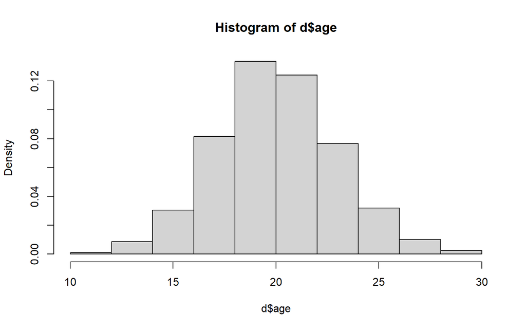

```r
#Variable = age
hist(d$age, probability = TRUE)
```

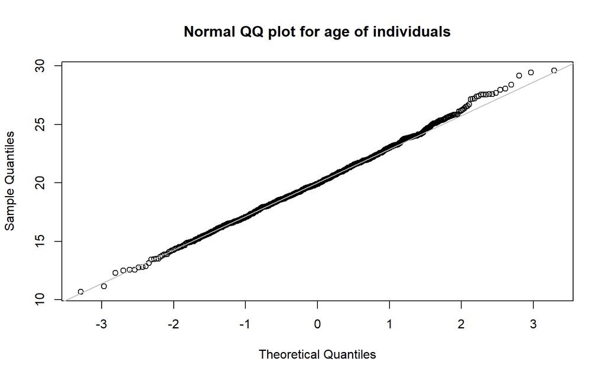

```r
qqnorm(d$age, main = "Normal QQ plot for age of individuals")
qqline(d$age, col = "gray") # fits with the QQ-line quite well (except the tails), can be roughly estimated to a normal distribution
```

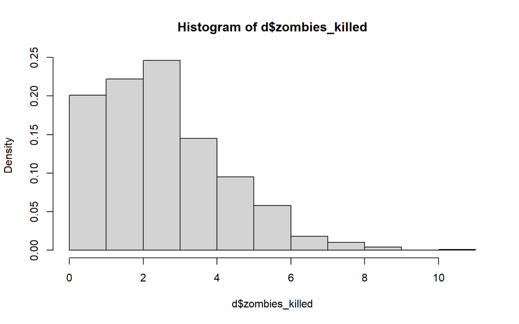

```r
#Variable = No. of zombies killed
hist(d$zombies_killed, probability = TRUE) #not a normal distribution
```

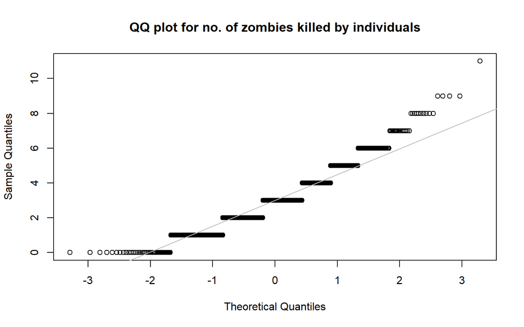

```r
qqnorm(d$zombies_killed, main = "QQ plot for no. of zombies killed by individuals")
qqline(d$zombies_killed, col = "gray") # Not a normal distribution
```

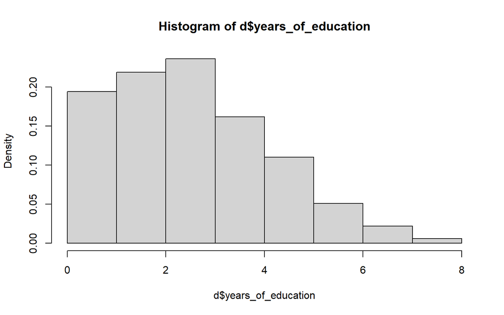

```r
#Variable = years of education
hist(d$years_of_education, probability = TRUE) #not a normal distribution
```

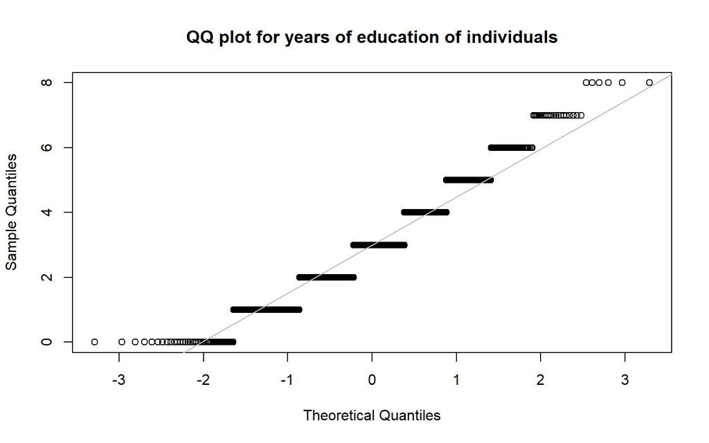

```r
qqnorm(d$years_of_education, main = "QQ plot for years of education of individuals")
qqline(d$years_of_education, col = "gray") # Not a normal distribution
```

Age, height and weight seem to be the variables that are derived from normal distributions. Their histograms are bell-shaped curves and the points align with the QQ-norm line well. Some deviation is expected at the extremes.

However, neither the “zombies_killed” nor the “years of education” variable was normally distributed. I would guess that these variables are poisson distributed, where the random variable X is the number of zombies killed, or the years or education respectively. This is also echoed in the qq-plots.

## Question 5: Now use the sample() function to sample ONE subset of 30 zombie survivors (without replacement) from this population and calculate the mean and sample standard deviation for each variable. Also estimate the standard error for each variable, and construct the 95% confidence interval for each mean.

```r
#creating a different sample (n=30) for each variable
set.seed(1)

sampledat <- function(x) {
  sample(x, size = 30, replace = FALSE)
}
#reesehs: again with the functions, this is such a better and more efficent way to code!

#For variable = weight
s<- sampledat(d$weight)
m <- mean(s)
sd(s) #can use this now because this is a sample not population?
```

```
## [1] 16.22658
```

```r
sem <- sd(s)/sqrt(30)
lower <- m - qnorm(1 - 0.05/2) * sem  #because this is from a normal distribution
upper <- m + qnorm(1 - 0.05/2) * sem
ci <- c(lower, upper)
ci
```

```
## [1] 136.4471 148.0601
```

```r
s_weight <- s

#For variable = height
s<- sampledat(d$height)
m <- mean(s)
sd(s) #can use this now because this is a sample not population?
```

```
## [1] 4.799765
```

```r
sem <- sd(s)/sqrt(30)
lower <- m - qnorm(1 - 0.05/2) * sem  #because this is from a normal distribution
upper <- m + qnorm(1 - 0.05/2) * sem
ci <- c(lower, upper)
ci
```

```
## [1] 67.15836 70.59345
```

```r
#reesehs: I do believe that we can use the sd() function because we're working on sample data now?
#vbhavya: thanks for the confirmation!

s_height <- s

#For variable = age
s<- sampledat(d$age)
m <- mean(s)
sd(s) #can use this now because this is a sample not population?
```

```
## [1] 3.477191
```

```r
sem <- sd(s)/sqrt(30)
lower <- m - qnorm(1 - 0.05/2) * sem  #because this is from a normal distribution
upper <- m + qnorm(1 - 0.05/2) * sem
ci <- c(lower, upper)
ci
```

```
## [1] 18.70344 21.19199
```

```r
s_age <- s
```

For the variables above that are from a normal distribution, the way to calculate the 95% CI is pretty straightforward. However, for variables like “zombies_killed” or “years_of_”education”, which I suspect are from a poisson distribution each, we can use the Central Limit Theorem to make normal approximations of the poisson distributions. These can then be used to find the 95% CIs for the variables.

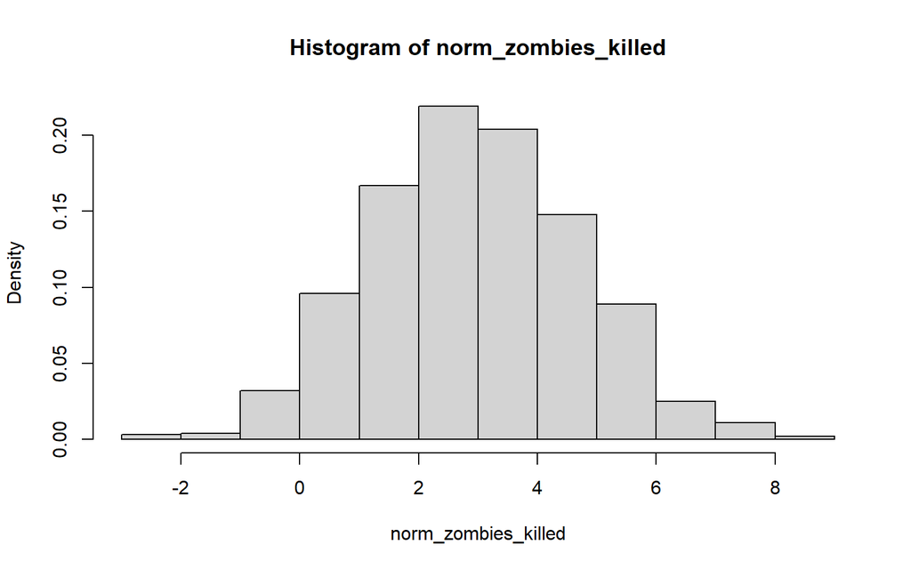

```r
# Variable: Zombies killed
lambda <- mean(d$zombies_killed)
stdev <- sqrt(lambda)

#reesehs: it seems like you have an amazing grasp on the material, I'm so jealous!
#vbhavya: I'm not sure if my approaches are correct. But I tried my best!

#normal approximation:
norm_zombies_killed <- rnorm(n=1000, mean = lambda, sd = stdev)
hist(norm_zombies_killed, probability = TRUE) #looks like a normal distribution now
```

```r
#norm_zombies_killed is our new population for zombies_killed now, which is normally approximated

s<- sampledat(norm_zombies_killed)
m <- mean(s)
sd(s) #can use this now because this is a sample not population?
```

```
## [1] 1.938451
```

```r
sem <- sd(s)/sqrt(30)
lower <- m - qnorm(1 - 0.05/2) * sem  #because this is from a normal distribution
upper <- m + qnorm(1 - 0.05/2) * sem
ci <- c(lower, upper)
ci #CI for norm_zombies_killed
```

```
## [1] 2.146712 3.534018
```

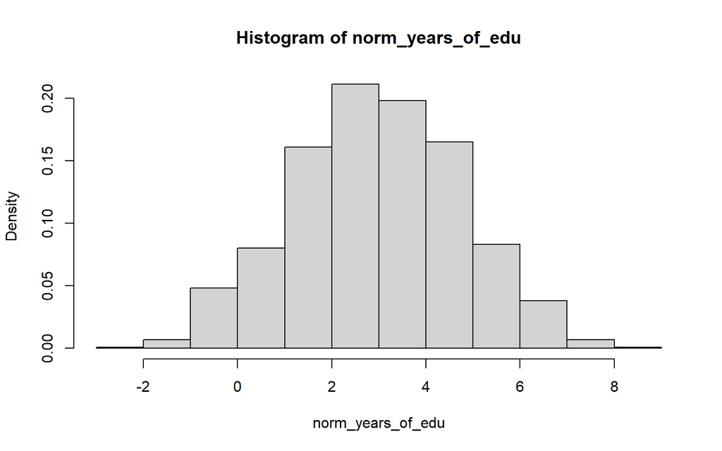

```r
#reesehs: I really liked how you did this and explained it in your comments!

s_zombies_killed <- s

# Variable: years of education
lambda <- mean(d$years_of_education)
stdev <- sqrt(lambda)

#normal approximation:
norm_years_of_edu <- rnorm(n=1000, mean = lambda, sd = stdev)
hist(norm_years_of_edu, probability = TRUE) #looks like a normal distribution now
```

```r
#norm_years_of_edu is our new population for years_of_education now, which is normally approximated

s<- sampledat(norm_years_of_edu)
m <- mean(s)
sd(s) #can use this now because this is a sample not population?
```

```
## [1] 1.760086
```

```r
sem <- sd(s)/sqrt(30)
lower <- m - qnorm(1 - 0.05/2) * sem  #because this is from a normal distribution
upper <- m + qnorm(1 - 0.05/2) * sem
ci <- c(lower, upper)
ci #CI for norm_years_of_edu
```

```
## [1] 1.894345 3.153999
```

```r
s_education <- s
```

## Question 6: Now draw 99 more random samples of 30 zombie apocalypse survivors, and calculate the mean for each variable for each of these samples. Together with the first sample you drew, you now have a set of 100 means for each variable (each based on 30 observations), which constitutes a sampling distribution for each variable. What are the means and standard deviations of this distribution of means for each variable?

### Variable: Weight

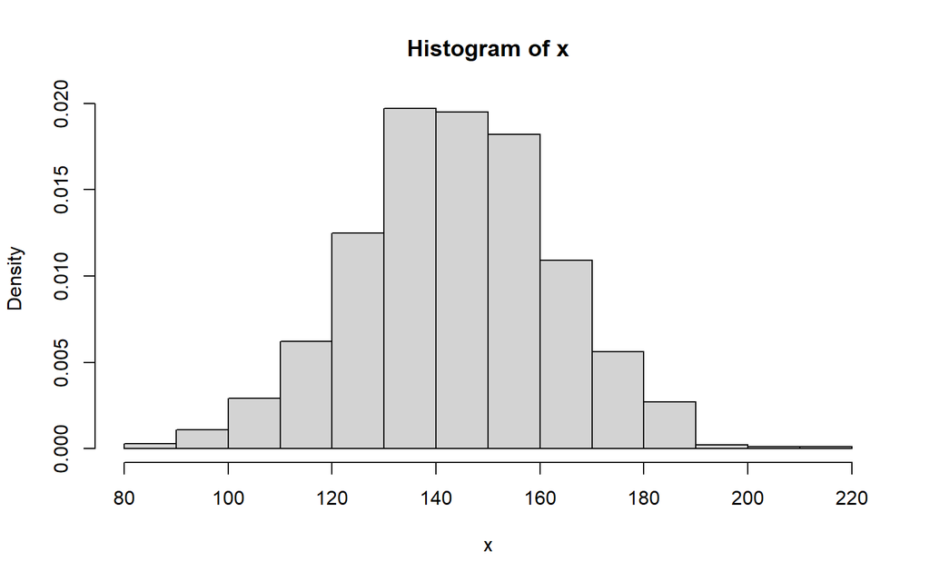

```r
stdev <- function(y) {
  sqrt(sum((y - mean(y))^2)/length(y))}
#reesehs: do functions carry over from different chunks? If so, you might not need to restate this function. But I'm not really sure!
#vbhavya: I din't think they do. At least, when I tried it, it didn't work.

set.seed(1)
y <- d$weight #change variable every time
x <- rnorm(1000, mean(y), stdev(y))
hist(x, probability = TRUE) #Making a histogram to check the distribution of the sample distribution. Because of CLT, it is expected to be normal
```

```r
#reesehs: you might want to note in your code why you are creating a histogram at this point? I'm a little confused!
#vbhavya: Done

k <- 99  # number of samples.
n <- 30  # size of each sample
s <- NULL  # dummy variable to hold each sample
for (i in 1:k) {
    s[[i]] <- sample(x, size = n, replace = FALSE)
}

s[[100]] <- s_weight # appending the sample of size n from question 5 to the sampling distribution
head(s)
```

```
## [[1]]
##  [1] 139.57882 150.32457 213.98554 164.59705 136.73247 192.63058 178.62164
##  [8] 148.16512 156.33566  90.77486 163.45986 132.65118 143.95191 157.38411
## [15] 140.63468 137.75942 113.30952 101.02296 149.46669 145.66122 126.54007
## [22] 121.85611 121.97856 119.28445 132.21866 155.30449 137.87839 136.48201
## [29] 121.37762 166.81907
##
## [[2]]
##  [1] 122.4824 142.8610 156.1801 180.7964 152.1916 125.9652 140.2545 152.0163
##  [9] 163.7311 160.4681 143.5955 129.9105 153.1966 174.9690 184.4818 134.8283
## [17] 167.4901 137.9435 131.3802 136.1467 128.3543 139.5788 157.4866 158.9359
## [25] 129.7532 110.7109 157.0891 130.0985 147.9973 154.4002
##
## [[3]]
##  [1] 171.7119 156.7857 119.3496 113.2894 187.1190 166.1232 132.3983 149.4771
```

[output cut: 23 more lines]

```r
#we now have sampling distribution for weight
#Now, we calculate the mean and standard distributions of the sampling distribution
z <- NULL
for (i in 1:100) {
    z[i] <- mean(s[[i]]) #this is now the sampling distribution of sample means
}


mean(z)
```

```
## [1] 143.5722
```

```r
sd(z)
```

```
## [1] 3.46294
```

```r
mean(s[[100]])
```

```
## [1] 142.2536
```

```r
sd(s[[100]])
```

```
## [1] 16.22658
```

#### How do the standard deviations of means compare to the standard errors estimated in [5]?

Answer: The mean and standard deviation of the sampling distribution are: 143.5722 and 3.46294 mean and standard deviation from 1 sample from [5]: 142.2536 and 16.22658 The means are quite similar but the standard deviation is much smaller when the samples are pooled together v/s when theres only 1 sample of n=30.

#### What do these sampling distributions look like (a graph might help here)? Are they normally distributed?

Yes, the distribution seems somewhat normal (for an n=30).

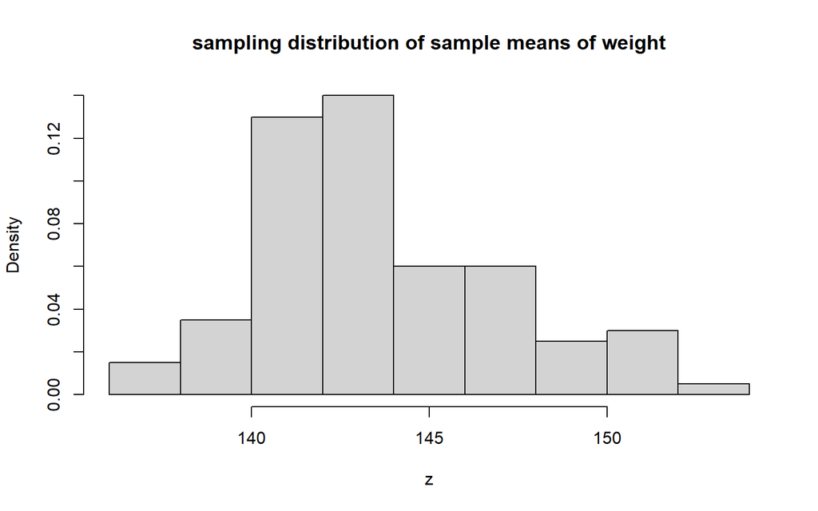

```r
hist(z, probability = TRUE, main = "sampling distribution of sample means of weight")
```

### Variable: Height

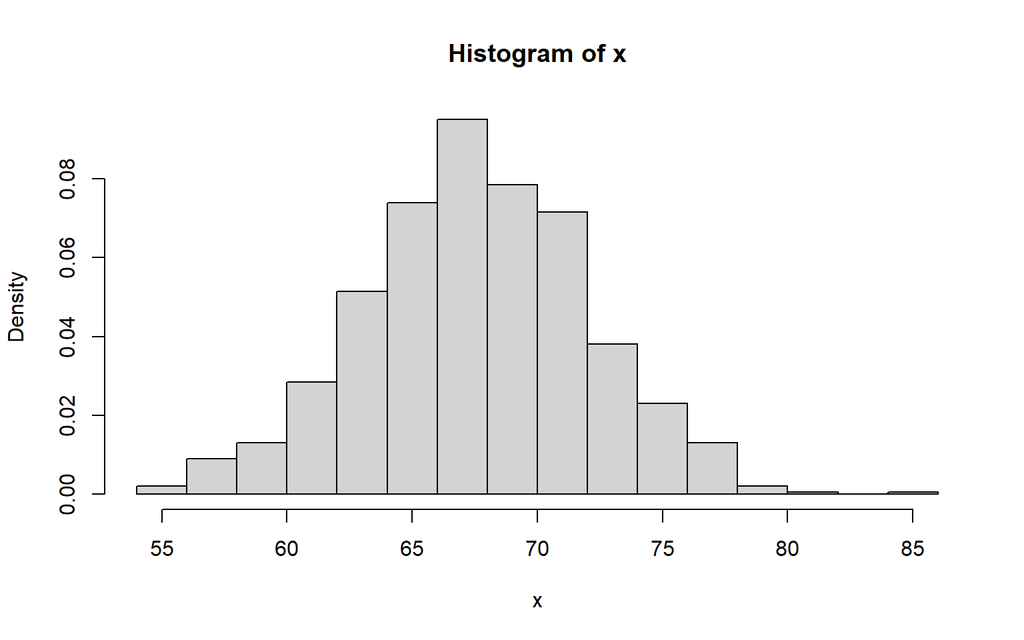

```r
stdev <- function(y) {
  sqrt(sum((y - mean(y))^2)/length(y))}


set.seed(1)
y <- d$height #change variable every time
x <- rnorm(1000, mean(y), stdev(y))
hist(x, probability = TRUE)
```

```r
k <- 99  # number of samples.
n <- 30  # size of each sample
s <- NULL  # dummy variable to hold each sample
for (i in 1:k) {
    s[[i]] <- sample(x, size = n, replace = FALSE)
}

s[[100]] <- s_height # appending the sample of size n from question 5 to the sampling distribution
head(s)
```

```
## [[1]]
##  [1] 66.61619 69.13319 84.04466 72.47627 65.94948 79.04263 75.76128 68.62738
##  [9] 70.54118 55.18471 72.20990 64.99351 67.64051 70.78676 66.86350 66.19002
## [17] 60.46306 57.58515 68.93225 68.04088 63.56209 62.46495 62.49363 61.86258
## [25] 64.89220 70.29965 66.21789 65.89081 62.35287 72.99674
##
## [[2]]
##  [1] 62.61165 67.38499 70.50476 76.27067 69.57051 63.42744 66.77445 69.52944
##  [9] 72.27345 71.50914 67.55703 64.35156 69.80591 74.90571 77.13392 65.50346
## [17] 73.15392 66.23315 64.69580 65.81227 63.98704 66.61619 70.81078 71.15024
## [25] 64.31472 59.85439 70.71765 64.39559 68.58806 70.08783
##
## [[3]]
##  [1] 74.14281 70.64660 61.87784 60.45834 77.75165 72.83373 64.93426 68.93467
##  [9] 70.45204 57.78537 65.34819 65.45045 62.64762 72.35115 66.79953 64.79152
## [17] 67.05089 63.52125 65.36345 65.75136 65.57024 58.08924 61.87736 63.59826
## [25] 67.60708 70.81623 68.24720 72.02623 73.93950 70.80599
##
## [[4]]
##  [1] 61.35499 70.54775 66.30005 71.63156 67.24239 71.13356 65.81053 68.41776
##  [9] 64.33067 63.60603 66.42769 64.62607 70.54424 69.20071 59.13075 75.17782
## [17] 69.84729 69.62753 67.93717 66.35633 57.18621 66.56831 68.58519 67.43749
## [25] 66.66776 66.86714 75.27141 63.44887 75.39188 62.93194
##
## [[5]]
##  [1] 66.25158 72.31351 72.14877 66.92134 66.56169 64.57167 66.86616 61.08890
##  [9] 69.06303 70.39685 70.08783 66.33350 68.51393 66.31265 63.13901 66.60201
## [17] 70.04610 63.30334 79.15711 73.83856 65.54515 64.94602 59.90874 71.77306
## [25] 65.80308 65.81134 73.93950 61.54722 71.20732 59.13075
##
## [[6]]
##  [1] 54.96564 65.18029 60.65603 67.67875 69.09963 68.63601 63.21637 67.45072
##  [9] 65.92847 74.57604 74.78081 71.91774 69.02160 64.37369 68.10874 65.80487
## [17] 70.04610 73.94366 67.46797 58.45688 63.60422 72.19001 64.20728 67.95132
## [25] 63.64045 64.61324 66.52937 62.23096 58.86336 68.35595
```

```r
#we now have sampling distribution for height
#Now, we calculate the mean and standard distributions of the sampling distribution
z <- NULL
for (i in 1:100) {
    z[i] <- mean(s[[i]]) #this is now the sampling distribution of sample means
}


mean(z)
```

```
## [1] 67.56789
```

```r
sd(z)
```

```
## [1] 0.8212308
```

```r
mean(s[[100]])
```

```
## [1] 68.87591
```

```r
sd(s[[100]])
```

```
## [1] 4.799765
```

#### What do these sampling distributions look like (a graph might help here)? Are they normally distributed?

Yes, the distribution seems somewhat normal (for an n=30), but the one for weight looked more normal in comparison.

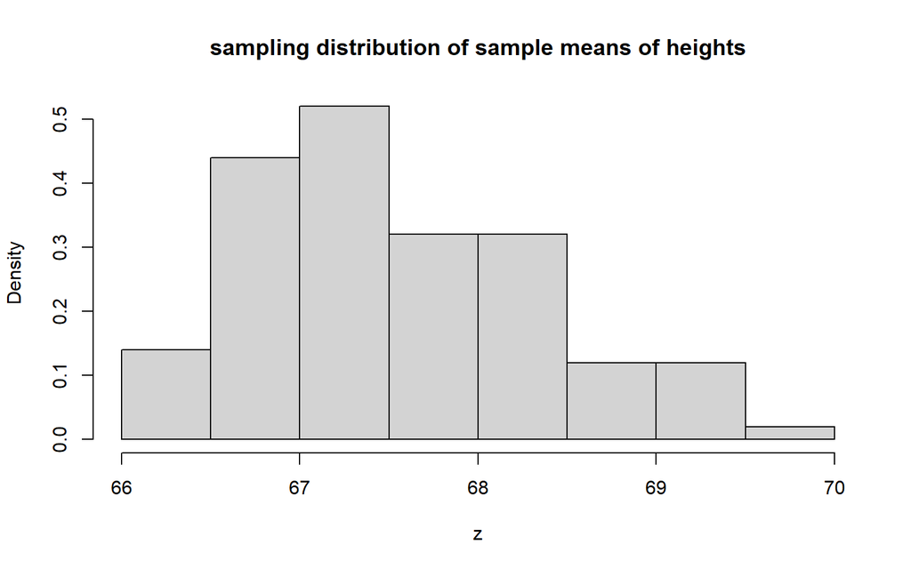

```r
hist(z, probability = TRUE, main = "sampling distribution of sample means of heights")
```

### Variable: Age

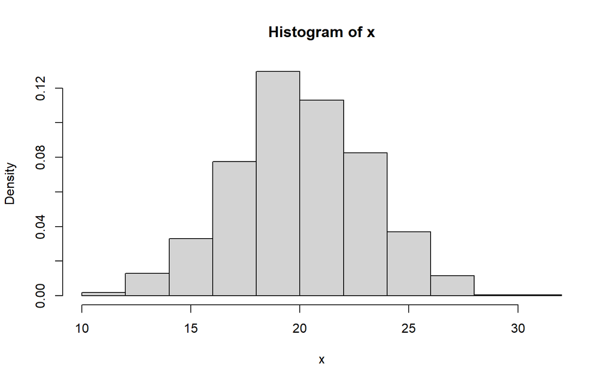

```r
stdev <- function(y) {
  sqrt(sum((y - mean(y))^2)/length(y))}


set.seed(1)
y <- d$age #change variable every time
x <- rnorm(1000, mean(y), stdev(y))
hist(x, probability = TRUE)
```

```r
k <- 99  # number of samples.
n <- 30  # size of each sample
s <- NULL  # dummy variable to hold each sample
for (i in 1:k) {
    s[[i]] <- sample(x, size = n, replace = FALSE)
}

s[[100]] <- s_age # appending the sample of size n from question 5 to the sampling distribution
head(s)
```

```
## [[1]]
##  [1] 19.34946 21.08098 31.33903 23.38079 18.89081 27.89799 25.64065 20.73302
##  [9] 22.04958 11.48541 23.19755 18.23317 20.05412 22.21853 19.51960 19.05629
## [17] 15.11654 13.13674 20.94275 20.32955 17.24845 16.49370 16.51343 16.07931
## [25] 18.16348 21.88343 19.07546 18.85045 16.41660 23.73883
##
## [[2]]
##  [1] 16.59462 19.87834 22.02452 25.99107 21.38183 17.15583 19.45833 21.35357
##  [9] 23.24126 22.71547 19.99669 17.79156 21.54377 25.05208 26.58493 18.58398
## [17] 23.84696 19.08596 18.02837 18.79642 17.54079 19.34946 22.23505 22.46857
## [25] 17.76621 14.69782 22.17098 17.82185 20.70597 21.73771
##
## [[3]]
##  [1] 24.52725 22.12210 16.08981 15.11329 27.00988 23.62670 18.19242 20.94442
##  [9] 21.98826 13.27448 18.47716 18.54751 16.61936 23.29472 19.47559 18.09422
## [17] 19.64851 17.22036 18.48766 18.75452 18.62992 13.48351 16.08948 17.27334
## [25] 20.03112 22.23879 20.47149 23.07119 24.38739 22.23175
##
## [[4]]
##  [1] 15.73012 22.05410 19.13198 22.79969 19.78024 22.45710 18.79523 20.58882
##  [9] 17.77718 17.27869 19.21979 17.98040 22.05168 21.12743 14.20001 25.23926
## [17] 21.57223 21.42105 20.25821 19.17070 12.86230 19.31653 20.70400 19.91446
## [25] 19.38494 19.52210 25.30365 17.17057 25.38652 16.81496
##
## [[5]]
##  [1] 19.09864 23.26882 23.15549 19.55938 19.31197 17.94298 19.52143 15.54707
##  [9] 21.03272 21.95030 21.73771 19.15499 20.65498 19.14065 16.95741 19.33971
## [17] 21.70900 17.07045 27.97674 24.31795 18.61266 18.20050 14.73521 22.89703
## [25] 18.79010 18.79578 24.38739 15.86237 22.50784 14.20001
##
## [[6]]
##  [1] 11.33470 18.36166 15.24929 20.08043 21.05790 20.73896 17.01063 19.92356
##  [9] 18.87636 24.82528 24.96615 22.99656 21.00422 17.80678 20.37623 18.79133
## [17] 21.70900 24.39025 19.93543 13.73642 17.27744 23.18386 17.69230 20.26794
## [25] 17.30236 17.97158 19.28973 16.33273 14.01606 20.54630
```

```r
#we now have sampling distribution for age
#Now, we calculate the mean and standard distributions of the sampling distribution
z <- NULL
for (i in 1:100) {
    z[i] <- mean(s[[i]]) #this is now the sampling distribution of sample means
}


mean(z)
```

```
## [1] 19.99461
```

```r
sd(z)
```

```
## [1] 0.5576102
```

```r
mean(s[[100]])
```

```
## [1] 19.94772
```

```r
sd(s[[100]])
```

```
## [1] 3.477191
```

#### What do these sampling distributions look like (a graph might help here)? Are they normally distributed?

Yes, the distribution seems somewhat normal (for an n=30).

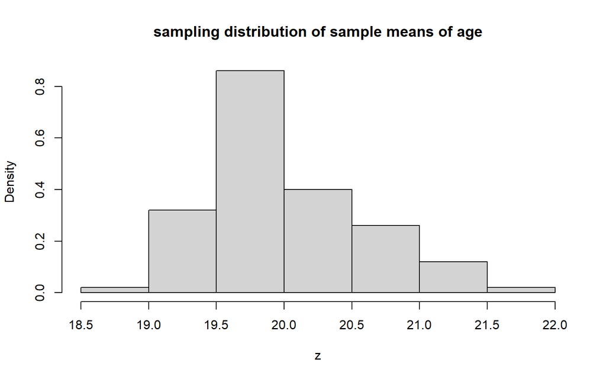

```r
hist(z, probability = TRUE, main = "sampling distribution of sample means of age")
```

### Variable: No. of Zombies Killed

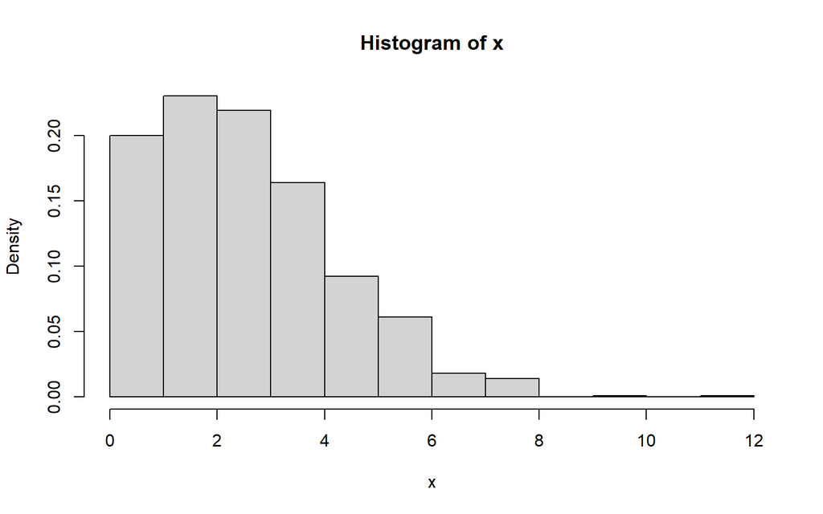

```r
set.seed(1)
y <- d$zombies_killed #change variable every time
x <- rpois(1000, lambda = mean(y)) #Using rpois() instead of rnorm() because the zombies_killed data is a Poisson distribution, unlike age, weight and height.
hist(x, probability = TRUE)
```

```r
#reesehs: I wonder if you could explain why you are using rpois? Is is necessary? I'm just genuinely curious!
#vbhavya: Done

k <- 99  # number of samples.
n <- 30  # size of each sample
s <- NULL  # dummy variable to hold each sample
for (i in 1:k) {
    s[[i]] <- sample(x, size = n, replace = FALSE)
}

head(s)
```

```
## [[1]]
##  [1] 4 4 4 3 6 4 4 1 4 1 1 2 2 4 4 4 3 3 2 2 6 5 3 4 6 0 2 4 3 2
##
## [[2]]
##  [1] 2 1 4 2 7 2 0 4 2 6 3 5 3 4 2 5 4 4 4 3 4 2 3 2 2 2 3 6 6 6
##
## [[3]]
##  [1] 4 6 2 3 1 5 7 0 3 2 2 1 2 5 4 2 4 2 2 4 3 6 2 1 6 2 2 2 3 6
##
## [[4]]
##  [1] 1 2 4 1 2 3 2 3 3 4 4 3 5 3 3 3 4 5 0 4 3 6 4 1 4 3 5 2 1 2
##
## [[5]]
##  [1] 0 1 3 2 4 1 2 3 5 1 2 6 4 3 4 6 5 4 2 5 2 1 2 4 3 1 3 4 2 6
##
## [[6]]
##  [1]  2  7  1  4  3  2  1  4  2  1  3  4  1  1  2  2  2  2  2 10  3  3  6  2  2
## [26]  4  6  3  1  4
```

```r
#we now have sampling distribution for zombies killed
#Now, we calculate the mean and standard distributions of the sampling distribution
z <- NULL
for (i in 1:99) {
    z[i] <- mean(s[[i]]) #this is now the sampling distribution of sample means
}

z[100] <- mean(s_zombies_killed) #instead of adding the sample information for question 5 to s, I am adding the mean of the sample from question 5 to the sampling distribution of sample means because the first 99 samples in s are poisson and the sample from question 5 is normal approximation of a poisson

mean(z)
```

```
## [1] 3.024737
```

```r
sd(z)
```

```
## [1] 0.3116313
```

```r
mean(s_zombies_killed)
```

```
## [1] 2.840365
```

```r
sd(s_zombies_killed)
```

```
## [1] 1.938451
```

#### What do these sampling distributions look like (a graph might help here)? Are they normally distributed?

Yes, the distribution seems somewhat normal (for an n=30). This happens even though the population isn’t normally distributed.

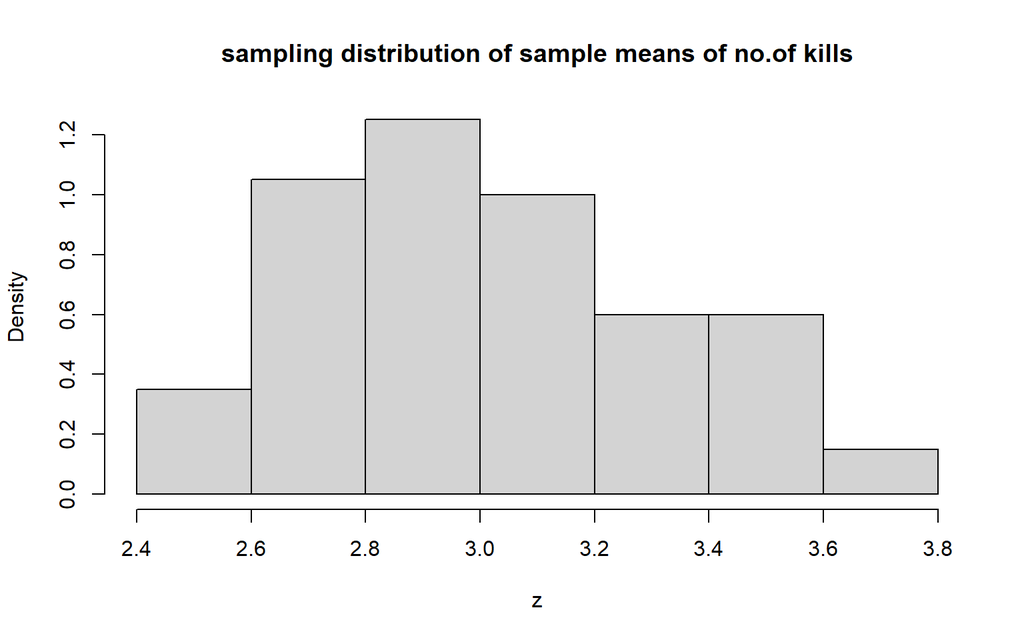

```r
hist(z, probability = TRUE, main = "sampling distribution of sample means of no.of kills")
```

### Variable: Years of Education

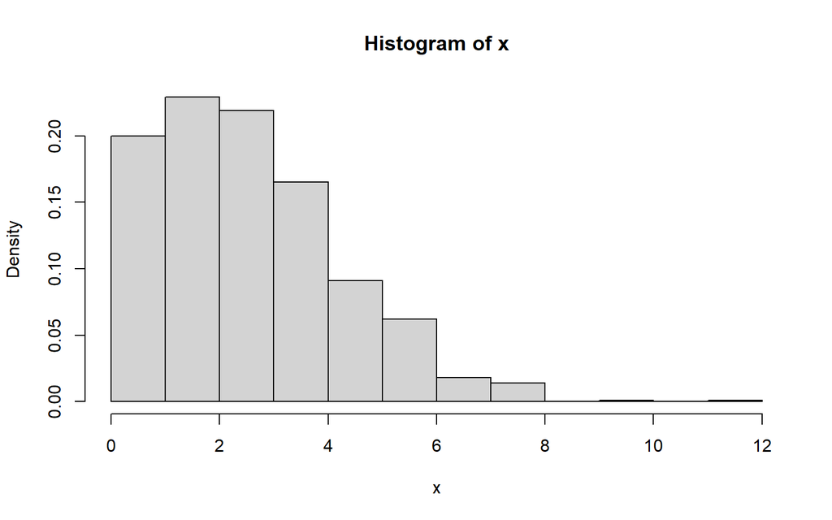

```r
set.seed(1)
y <- d$years_of_education #change variable every time
x <- rpois(1000, lambda = mean(y)) #Using rpois() instead of rnorm()
hist(x, probability = TRUE)
```

```r
k <- 99  # number of samples.
n <- 30  # size of each sample
s <- NULL  # dummy variable to hold each sample
for (i in 1:k) {
    s[[i]] <- sample(x, size = n, replace = FALSE)
}

head(s)
```

```
## [[1]]
##  [1] 4 4 4 3 6 4 4 1 4 1 1 2 2 4 4 4 3 3 2 2 6 5 3 4 6 0 2 4 3 2
##
## [[2]]
##  [1] 2 1 4 2 7 2 0 4 2 6 3 5 3 4 2 5 4 4 4 3 4 2 3 2 2 2 3 6 6 6
##
## [[3]]
##  [1] 4 6 2 3 1 5 7 0 3 2 2 1 2 5 4 2 4 2 2 4 3 6 2 1 6 2 2 2 3 6
##
## [[4]]
##  [1] 1 2 4 1 2 3 2 3 3 4 4 3 5 3 3 3 4 5 0 4 3 6 4 1 4 4 5 2 1 2
##
## [[5]]
##  [1] 0 1 3 2 4 1 2 3 5 1 2 6 4 3 4 6 5 4 2 5 2 1 2 4 3 1 3 4 2 6
##
## [[6]]
##  [1]  2  7  1  4  3  2  1  4  2  1  3  4  1  1  2  2  2  2  2 10  3  3  6  2  2
## [26]  4  6  3  1  4
```

```r
#we now have sampling distribution for years of education
#Now, we calculate the mean and standard distributions of the sampling distribution
z <- NULL
for (i in 1:99) {
    z[i] <- mean(s[[i]]) #this is now the sampling distribution of sample means
}

z[100] <- mean(s_education) #instead of adding the sample information for question 5 to s, I am adding the mean of the sample from question 5 to the sampling distribution of sample means because the first 99 samples in s are poisson and the sample from question 5 is normal approximation of a poisson

mean(z)
```

```
## [1] 3.023908
```

```r
sd(z)
```

```
## [1] 0.3153095
```

```r
mean(s_education)
```

```
## [1] 2.524172
```

```r
sd(s_education)
```

```
## [1] 1.760086
```

#### What do these sampling distributions look like (a graph might help here)? Are they normally distributed?

Yes, the distribution seems somewhat normal (for an n=30). This happens even though the population isn’t normally distributed.

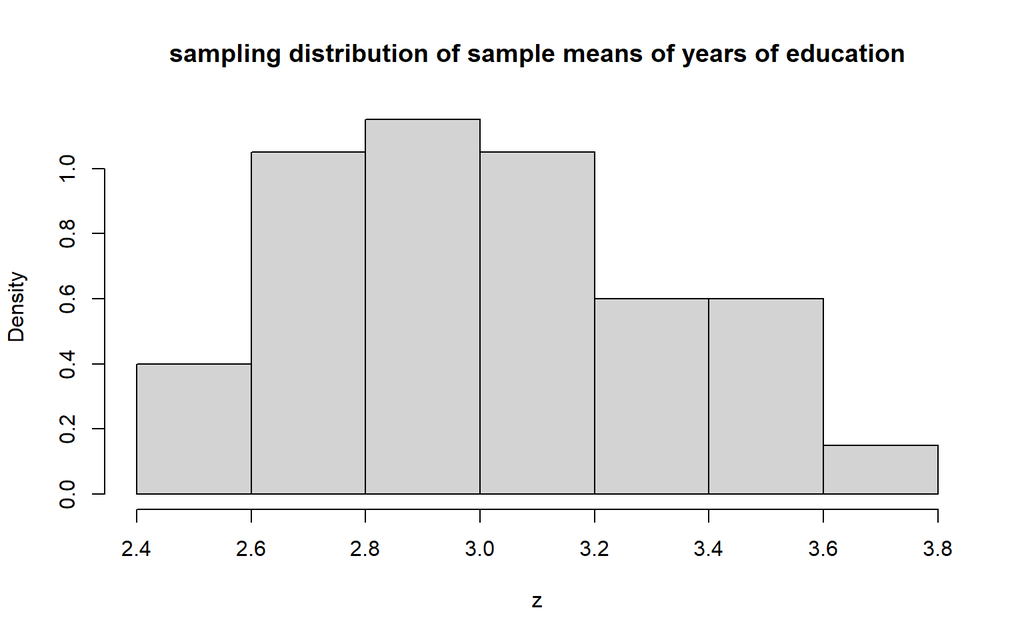

```r
hist(z, probability = TRUE, main = "sampling distribution of sample means of years of education")
```

## Challenges I faced: 1. I think there were so many variables and the code I wrote doesn’t feel very efficient. 2. I had a hard time figuring out what the distribution for zombies_killed and years_of_education was. Initially I thought it was binomial but it seems like Poisson 3. I had normally approximated the poisson distributions, so combining the sample from question 5 and the other 99 samples from question 6 needed to be different from the normally distributed variables 4. I had to update R. Not fun.

## Peer Commentary:

I thought that you did an amazing job and I’m really in awe of your organization and efficent code! I left suggestions throughout your code, but there’s not much I can really do to help since you seem to have everything figured out! The only thing is at the end when you were doing histograms before each variable I was a little confused. So if you could just make a comment explaining I think that would be really helpful. Other than that I’m so glad that I got to see your code! Please let me know if you have any questions

## Response to Peer Commentary:

I was really grateful for the suggestions about adding explanations. I think I was doing things because they felt right but being forced to express them really help with making it clearer as to why I might be doing a particular step.